# Amazon Data Scientist Mock Interview

```python
import pandas as pd
import numpy as np
```

```python
customers = pd.read_csv('https://storage.googleapis.com/datalynn-datasets/interview-challenge/e-commerce-and-online-service/Amazon_Purchase/customers.csv')
products = pd.read_csv('https://storage.googleapis.com/datalynn-datasets/interview-challenge/e-commerce-and-online-service/Amazon_Purchase/products.csv')
customer_behavior = pd.read_csv('https://storage.googleapis.com/datalynn-datasets/interview-challenge/e-commerce-and-online-service/Amazon_Purchase/customer_behavior.csv')
```

```python
customers.head()
```

|  | Customer_Id | Age | Gender | Location | Tenure | Avg_Session_Duration_min | No_of_Purchases |
| --- | --- | --- | --- | --- | --- | --- | --- |
| 0 | 0 | 35 | F | City_B | 4.0 | 16.294556 | 87 |
| 1 | 1 | 44 | F | City_B | 9.0 | 11.181317 | 68 |
| 2 | 2 | 38 | M | City_D | 1.0 | 5.384545 | 19 |
| 3 | 3 | 35 | M | City_A | 4.0 | 23.113886 | 25 |
| 4 | 4 | 30 | M | City_C | NaN | 16.425295 | 34 |

```python
products.head()
```

|  | Product_Id | Category | Brand | Price | Rating |
| --- | --- | --- | --- | --- | --- |
| 0 | 0 | Groceries | Brand_G1 | 8.074025 | 3.8 |
| 1 | 1 | Clothing | Brand_C3 | 33.990447 | 4.2 |
| 2 | 2 | Groceries | Brand_G3 | 13.514675 | 3.4 |
| 3 | 3 | Electronic | Brand_E2 | 369.359531 | 4.0 |
| 4 | 4 | Groceries | Brand_G3 | 12.930961 | 3.4 |

```python
customer_behavior.head()
```

|  | Customer_Id | Product_Id | Clicked | Added_to_Cart | Purchased |
| --- | --- | --- | --- | --- | --- |
| 0 | 0 | 216 | 0 | 0 | 0 |
| 1 | 0 | 216 | 1 | 1 | 1 |
| 2 | 0 | 216 | 0 | 0 | 0 |
| 3 | 0 | 216 | 1 | 1 | 0 |
| 4 | 0 | 216 | 0 | 0 | 0 |

## Data Manipulation

### 1.1 Given these datasets, how would you integrate them to create a comprehensive view of the customer-product interaction?

```python
# merge the datasets
merged_data = pd.merge(customer_behavior, customers, on='Customer_Id')
merged_data = pd.merge(merged_data, products, on='Product_Id')
```

### 1.2 The datasets may not be perfect. If you encounter any data quality issues such as missing data or discrepancies, how would you handle them?

```python
# Check for missing data
merged_data.isnull().sum()
```

```
Customer_Id                   0
Product_Id                    0
Clicked                       0
Added_to_Cart                 0
Purchased                     0
Age                           0
Gender                        0
Location                      0
Tenure                      200
Avg_Session_Duration_min    200
No_of_Purchases               0
Category                      0
Brand                       200
Price                         0
Rating                        0
dtype: int64
```

```python
mean_value = merged_data['Avg_Session_Duration_min'].mean()
merged_data['Avg_Session_Duration_min'].fillna(mean_value, inplace=True)
```

We can also use ML algorithms like K-Nearest Neighbors to predict and impute missing values.

```python
from sklearn.impute import KNNImputer

imputer = KNNImputer(n_neighbors=3)
merged_data['Tenure'] = imputer.fit_transform(merged_data[['Tenure']])
```

```python
most_frequent_category = merged_data['Brand'].mode()[0]
merged_data['Brand'].fillna(most_frequent_category, inplace=True)
```

```python
merged_data.isnull().sum()
```

```
Customer_Id                 0
Product_Id                  0
Clicked                     0
Added_to_Cart               0
Purchased                   0
Age                         0
Gender                      0
Location                    0
Tenure                      0
Avg_Session_Duration_min    0
No_of_Purchases             0
Category                    0
Brand                       0
Price                       0
Rating                      0
dtype: int64
```

```python
merged_data.drop_duplicates(inplace=True)
```

## SQL Section: In this section, we will test your ability to write SQL codes. Below are the setup code blocks.

```python
!pip install pandasql
```

```
  Preparing metadata (setup.py) ... done
```

```python
import sqlite3

conn = sqlite3.connect('temp.db')

products.to_sql('product', conn, if_exists='replace', index=False)
customers.to_sql('customer', conn, if_exists='replace', index=False)
customer_behavior.to_sql('customer_behavior', conn, if_exists='replace', index=False)
```

```
10000
```

### 2.1 How would you write a SQL query to find the top 3 brands for each product category based on the average rating?

```python
query1 = '''
        SELECT category, brand, avg_rating
        FROM (
            SELECT category, brand, AVG(rating) as avg_rating,
                   ROW_NUMBER() OVER(PARTITION BY category ORDER BY AVG(rating) DESC) as rank
            FROM product
            GROUP BY category, brand
        )
        WHERE rank <= 3
        '''

df_result1 = pd.read_sql_query(query1, conn)
df_result1
```

|  | category | brand | avg_rating |
| --- | --- | --- | --- |
| 0 | Beauty | None | 4.300000 |
| 1 | Beauty | Brand_B4 | 4.300000 |
| 2 | Beauty | Brand_B2 | 3.600000 |
| 3 | Books | Brand_Bo1 | 3.900000 |
| 4 | Books | None | 3.800000 |
| 5 | Books | Brand_Bo2 | 3.700000 |
| 6 | Clothing | Brand_C3 | 4.200000 |
| 7 | Clothing | Brand_C2 | 3.800000 |
| 8 | Clothing | None | 3.600000 |
| 9 | Electronic | Brand_E1 | 4.400000 |
| 10 | Electronic | None | 4.133333 |
| 11 | Electronic | Brand_E2 | 4.000000 |
| 12 | Groceries | Brand_G2 | 4.000000 |
| 13 | Groceries | Brand_G1 | 3.800000 |
| 14 | Groceries | Brand_G3 | 3.400000 |

### 2.2 Can you write a SQL query to find customers who clicked on at least 1 product, have at least 1 item added to cart, but never purchased any product?

```python
query2 = '''
       SELECT cb.Customer_Id
        FROM (
            SELECT Customer_Id,
                   COUNT(DISTINCT CASE WHEN Purchased = 1 THEN Product_Id END) as purchase_count,
                   COUNT(DISTINCT CASE WHEN Clicked = 1 THEN Product_Id END) as click_count,
                   COUNT(DISTINCT CASE WHEN Added_to_Cart = 1 THEN Product_Id END) as add_to_cart_count
            FROM customer_behavior
            GROUP BY Customer_Id
        ) cb
        WHERE cb.click_count >= 1
        AND cb.add_to_cart_count >= 1
        AND cb.purchase_count = 0
        '''

df_result2 = pd.read_sql_query(query2, conn)
df_result2
```

|  | Customer_Id |
| --- | --- |
| 0 | 4 |
| 1 | 5 |
| 2 | 8 |
| 3 | 16 |
| 4 | 20 |
| ... | ... |
| 212 | 985 |
| 213 | 991 |
| 214 | 992 |
| 215 | 993 |
| 216 | 995 |

217 rows × 1 columns

### 3.1 Considering the provided datasets, we will look at some features that are worth manipulating. Let's use feature engineering to create new features.

1. One of the important metrics in e-commerce is to see how many products that the customer viewed are being added to their shopping cart. Can you come up with a new feature that shows this relationship?
2. Customer loyalty, represented by the term 'Tenure', could also play an important role in our prediction. However, this variable itself could be sometimes misleading. For example, a customer might be using Amazon for a long time but only have a few purchases, or the average session duration is very short. This could be an underlying issue when recommending products to those customers. Can you generate some new features to fix this issue?
3. Considering the potential variations in product pricing across different brands, how might you incorporate a brand-related feature that could help capture the effects of these pricing differences on customer purchasing behavior?

```python
#@title Feature Engineering
df_features = merged_data.copy()
# Create 'Click_To_Add_Ratio' feature
df_features['Click_To_Add_Ratio'] = np.where(df_features['Clicked'] == 1, df_features['Added_to_Cart'] / df_features['Clicked'], 0)

# Generate new terms that scale 'Avg_Session_Duration_min', 'Purchases_per_Year' and 'Age' based on 'Tenure'.
# Create Avg_Session_Duration_per_Year
df_features['Avg_Session_Duration_per_Year'] = df_features['Avg_Session_Duration_min'] / (df_features['Tenure'] + 1)

# Create Purchases_per_Year
df_features['Purchases_per_Year'] = df_features['No_of_Purchases'] / (df_features['Tenure'] + 1)

# Create Tenure_to_Age_Ratio
df_features['Tenure_to_Age_Ratio'] = df_features['Age'] / (df_features['Tenure'] + 1)

# Create Price_Ratio_Brand
brand_avg_price = df_features.groupby('Brand')['Price'].mean()
df_features['Avg_Price_Brand'] = df_features['Brand'].map(brand_avg_price)

df_features.head()
```

|  | Customer_Id | Product_Id | Clicked | Added_to_Cart | Purchased | Age | Gender | Location | Tenure | Avg_Session_Duration_min | No_of_Purchases | Category | Brand | Price | Rating | Click_To_Add_Ratio | Avg_Session_Duration_per_Year | Purchases_per_Year | Tenure_to_Age_Ratio | Avg_Price_Brand |
| --- | --- | --- | --- | --- | --- | --- | --- | --- | --- | --- | --- | --- | --- | --- | --- | --- | --- | --- | --- | --- |
| 0 | 0 | 216 | 0 | 0 | 0 | 35 | F | City_B | 4.0 | 16.294556 | 87 | Electronic | Brand_E1 | 191.077879 | 4.4 | 0.0 | 3.258911 | 17.4 | 7.0 | 304.057153 |
| 1 | 0 | 216 | 1 | 1 | 1 | 35 | F | City_B | 4.0 | 16.294556 | 87 | Electronic | Brand_E1 | 191.077879 | 4.4 | 1.0 | 3.258911 | 17.4 | 7.0 | 304.057153 |
| 3 | 0 | 216 | 1 | 1 | 0 | 35 | F | City_B | 4.0 | 16.294556 | 87 | Electronic | Brand_E1 | 191.077879 | 4.4 | 1.0 | 3.258911 | 17.4 | 7.0 | 304.057153 |
| 6 | 0 | 216 | 1 | 0 | 0 | 35 | F | City_B | 4.0 | 16.294556 | 87 | Electronic | Brand_E1 | 191.077879 | 4.4 | 0.0 | 3.258911 | 17.4 | 7.0 | 304.057153 |
| 10 | 312 | 216 | 0 | 0 | 0 | 20 | F | City_B | 3.0 | 22.527608 | 80 | Electronic | Brand_E1 | 191.077879 | 4.4 | 0.0 | 5.631902 | 20.0 | 5.0 | 304.057153 |

### 3.2 How would you handle categorical variables('Gender', 'Location', 'Category', 'Brand') in these datasets?

One-hot encoding is an easy and useful method in handling categorical variables. When working with categorical variables, we often encounter ordinal and nominal data. One-hot encoding does not impose any ordinality on nominal data.

```python
# One-Hot encode the 'Category' and 'Brand' columns
merged_data_encoded = pd.get_dummies(df_features, columns=['Gender', 'Location', 'Category', 'Brand'])

merged_data_encoded.head()
```

|  | Customer_Id | Product_Id | Clicked | Added_to_Cart | Purchased | Age | Tenure | Avg_Session_Duration_min | No_of_Purchases | Price | ... | Brand_Brand_Bo1 | Brand_Brand_Bo2 | Brand_Brand_C1 | Brand_Brand_C2 | Brand_Brand_C3 | Brand_Brand_E1 | Brand_Brand_E2 | Brand_Brand_G1 | Brand_Brand_G2 | Brand_Brand_G3 |
| --- | --- | --- | --- | --- | --- | --- | --- | --- | --- | --- | --- | --- | --- | --- | --- | --- | --- | --- | --- | --- | --- |
| 0 | 0 | 216 | 0 | 0 | 0 | 35 | 4.0 | 16.294556 | 87 | 191.077879 | ... | 0 | 0 | 0 | 0 | 0 | 1 | 0 | 0 | 0 | 0 |
| 1 | 0 | 216 | 1 | 1 | 1 | 35 | 4.0 | 16.294556 | 87 | 191.077879 | ... | 0 | 0 | 0 | 0 | 0 | 1 | 0 | 0 | 0 | 0 |
| 3 | 0 | 216 | 1 | 1 | 0 | 35 | 4.0 | 16.294556 | 87 | 191.077879 | ... | 0 | 0 | 0 | 0 | 0 | 1 | 0 | 0 | 0 | 0 |
| 6 | 0 | 216 | 1 | 0 | 0 | 35 | 4.0 | 16.294556 | 87 | 191.077879 | ... | 0 | 0 | 0 | 0 | 0 | 1 | 0 | 0 | 0 | 0 |
| 10 | 312 | 216 | 0 | 0 | 0 | 20 | 3.0 | 22.527608 | 80 | 191.077879 | ... | 0 | 0 | 0 | 0 | 0 | 1 | 0 | 0 | 0 | 0 |

5 rows × 41 columns

## Modeling

### 4.1 Assuming you have already built a baseline Random Forest model that predicts whether a customer will purchase a recommended product. Describe how you would conduct an evaluation of the model performance. Which metrics would you focus on for this specific task and why?

```python
#@title Random Forest and F1-Score
from sklearn.ensemble import RandomForestClassifier
from sklearn.model_selection import cross_val_score, KFold
from sklearn.metrics import make_scorer, accuracy_score, f1_score
from sklearn.model_selection import train_test_split

# Assume merged_data_encoded is the DataFrame after all feature engineering tasks

# Define the feature columns
feature_cols = merged_data_encoded.columns.drop('Purchased')

# Define X and y
X = merged_data_encoded[feature_cols]
y = merged_data_encoded['Purchased']

# Create a Random Forest Classifier
rf_model = RandomForestClassifier(n_estimators=100, random_state=42)
X_train, X_test, y_train, y_test = train_test_split(X,  y, test_size=0.2, random_state=42)

# Train the model
rf_model.fit(X_train, y_train)

# Make predictions on the test set
y_pred = rf_model.predict(X_test)

# Calculate the F1 score and confusion matrix
f1 = f1_score(y_test, y_pred, average = 'weighted')
print("F1 Score:", f1)
```

```
F1 Score: 0.6533776091081595
```

### 4.2 If your random forest model works well on training dataset but have a lower F1-score on testing dataset, what do you think are the causes of this problem? What methods can you think of to mitigate these issues, especially given that we're interested in utilizing a Random Forest model in this scenario? In particular, consider methods that help us make better use of our data for both training and validation purposes.

```python
#@title Random Forest and K-fold Cross Validation
# Import the necessary libraries
from sklearn.ensemble import RandomForestClassifier
from sklearn.model_selection import cross_val_score, KFold
from sklearn.metrics import make_scorer, accuracy_score, f1_score

# Assume merged_data_encoded is the DataFrame after all feature engineering tasks

# Define the feature columns
feature_cols = merged_data_encoded.columns.drop('Purchased')

# Define X and y
X = merged_data_encoded[feature_cols]
y = merged_data_encoded['Purchased']

# Create a Random Forest Classifier
rfc = RandomForestClassifier(n_estimators=100, random_state=42)
X_train, X_test, y_train, y_test = train_test_split(X,  y, test_size=0.2, random_state=42)

# Create a KFold object
kfold = KFold(n_splits=5, shuffle=True, random_state=42)

# Use cross_val_score for accuracy
accuracy_scores = cross_val_score(rfc, X_train, y_train, cv=kfold, scoring=make_scorer(accuracy_score))

# Use cross_val_score for F1-score
f1_scores = cross_val_score(rfc, X_train, y_train, cv=kfold, scoring=make_scorer(f1_score, average='weighted'))

print(f"Average 5-Fold CV F1-score: {np.mean(f1_scores):.2f}, Standard deviation: {np.std(f1_scores):.2f}")

# Fit the model on the training data
rfc.fit(X_train, y_train)

# Make predictions on the test set
y_pred = rfc.predict(X_test)

# Calculate F1-score on the test set
f1_score_test = f1_score(y_test, y_pred, average='weighted')

print("F1-score (Testing):", f1_score_test)
```

```
Average 5-Fold CV F1-score: 0.68, Standard deviation: 0.01
F1-score (Testing): 0.6533776091081595
```

### 4.3 Can you explain how you'd interpret the output of your model? Use a feature importance plot to show the result.

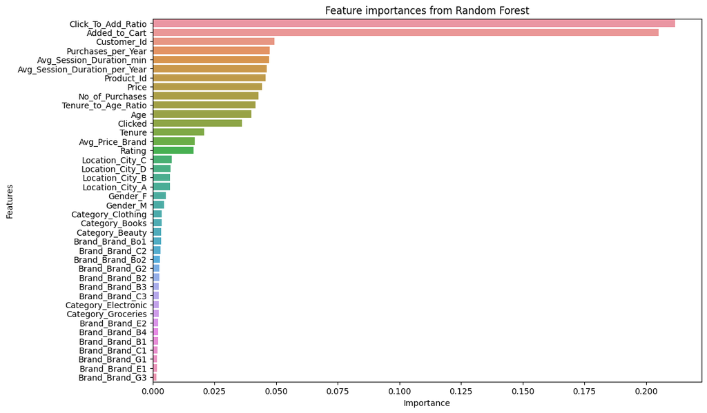

```python
# Import necessary libraries
import matplotlib.pyplot as plt
import seaborn as sns

# Get feature importances
importances = rfc.feature_importances_

# Convert the importances into one-dimensional 1darray with corresponding df column names as axis labels
f_importances = pd.Series(importances, X.columns)

# Sort the array in descending order of the importances
f_importances.sort_values(ascending=False, inplace=True)

# Make the bar Plot from f_importances
plt.figure(figsize=(12,8))
sns.barplot(x=f_importances, y=f_importances.index)
plt.xlabel('Importance')
plt.ylabel('Features')
plt.title('Feature importances from Random Forest')
plt.show()
```

### 4.4 While the Random Forest model has performed reasonably well so far, we're always looking for ways to further enhance our model's predictive power. There's a range of more complex ensemble methods that could potentially improve our results. How would you approach this? Consider ways that multiple models can be combined to leverage their individual strengths, and also take into account the need to handle data appropriately to ensure a fair comparison.

We use stacking method to improve our results. We use logistic regression and random forest as our base models and XGboost as our meta model. We standardized the data before fitting the model on the training dataset.

```python
from sklearn.preprocessing import StandardScaler
from sklearn.ensemble import StackingClassifier
from sklearn.ensemble import RandomForestClassifier
from sklearn.linear_model import LogisticRegression
from xgboost import XGBClassifier
from sklearn.metrics import f1_score

# Define the base models
base_models = [
    ("rf", RandomForestClassifier(n_estimators=500, random_state=42)),
    ("lr", LogisticRegression(max_iter=1000))
]

# Initialize Stacking Classifier with the Meta Model
stacking_model = StackingClassifier(estimators=base_models, final_estimator=XGBClassifier())

# Standardize the features
scaler = StandardScaler()
X_train_scaled = scaler.fit_transform(X_train)
X_test_scaled = scaler.transform(X_test)

# Fit the model to our training data and predict the labels of the test data
stacking_model.fit(X_train_scaled, y_train)

# Predicting the Test set results
y_pred = stacking_model.predict(X_test_scaled)

# Evaluating the model
print("F1 Score:", f1_score(y_test, y_pred, average='weighted'))
```

```
F1 Score: 0.8898438036262021
```

## Business Insights

### 5.1 What insights can you get from your model's output that could be used to inform business decisions? How might these insights improve our current recommendation system?

### 5.2 What are the potential business implications of your model's false positives and false negatives? How might you balance these considerations? OR How might different business contexts or goals influence which metrics we prioritize?